# *Keywords Extraction*

## *What is Keywords Extraction?*

*Keywords extraction is a subtask of the Information Extraction field which is responsible for extracting keywords from a given text or from a collection of texts to help us summarize the content. This is useful in the context of the huge amount of information we deal with every day. We need to index this information, to organise it and retrieve it later. Keywords extraction becomes more and more important these days and keywords extraction algorithms are researched and improved continuously.*

## *How does keyword extraction work?*

*A typical keyword extraction algorithm has three main components:*

- *Candidate selection* *: Here, we extract all possible words, phrases, terms or concepts (depending on the task) that can potentially be keywords.*
- *Properties calculation* *: For each candidate, we need to calculate properties that indicate that it may be a keyword. For example, a candidate appearing in the title of a book is a likely keyword.*
- *Scoring and selecting keywords* *: All candidates can be scored by either combining the properties into a formula, or using a machine learning technique to determine probability of a candidate being a keyword. A score or probability threshold, or a limit on the number of keywords is then used to select the final set of keywords..*

*Finally, parameters such as the minimum frequency of a candidate, its minimum and maximum length in words, or the stemmer used to normalize the candidates help tweak the algorithm’s performance to a specific dataset.*

## *Simple Statistical Approaches*

*Using statistics is one of the simplest methods for identifying the main keywords and key phrases within a text.*

*There are different types of statistical approaches, including **word frequency**, **word collocations and co-occurrences**, **TF-IDF (short for term frequency–inverse document frequency)**, and **RAKE (Rapid Automatic Keyword Extraction)**.*

*These approaches don’t require training data in order to extract the most important keywords in a text. However, due to the fact that they rely on stats, they may overlook relevant words or phrases that are mentioned once but are still considered relevant.*

### *Word Frequency*

*Word frequency consists of listing the words and phrases that most commonly appear within a text. This can be very useful for a myriad of purposes, from identifying recurrent terms in a set of product reviews, to finding out what are the most common issues in customer support interactions.*

*However, word frequency approaches consider documents as a mere ‘bag of words’, leaving aside crucial aspects related to the meaning, structure, grammar, and sequence of words. Synonyms, for example, can’t be detected by this keyword extraction method, dismissing very valuable information.*

### *Word Collocations and Co-occurrences*

*Also known as **N-gram statistics**, word collocations and co-occurrences can help you understand the semantic structure of a text and count separate words as one.*

*Collocations are words that frequently go together. The most common types of collocations are bi-grams (two terms that appear adjacently, like ‘customer service’, ‘video calls’ or ‘email notification’) and tri-grams (a group of three words, like ‘easy to use’ or ‘social media channels’).*

*Co-occurrences, on the other hand, refer to words that tend to co-occur in the same corpus. They don’t necessarily have to be adjacent, but they do have a semantic proximity.*

### *TF-IDF*

*TF-IDF stands for term frequency–inverse document frequency, a formula that measures how important a word is to a document in a collection of documents.*

*This metric calculates the number of times a word appears in a text (term frequency) and compares it with the inverse document frequency (how rare or common that word is in the entire data set).*

*Multiplying these two quantities provides the TF-IDF score of a word in a document. The higher the score is, the more relevant the word is to the document.*

*When it comes to keyword extraction, this metric can help you identify the most relevant words in a document (the ones with the higher scores) and consider them as keywords. This can be particularly useful for tasks like tagging customer support tickets or analyzing customer feedback.*

### *RAKE*

*Rapid Automatic Keyword Extraction (RAKE) is a well-known keyword extraction method which uses a list of stopwords and phrase delimiters to detect the most relevant words or phrases in a piece of text.*

*Take the following text as an example:*

`Keyword extraction is not that difficult after all. There are many libraries that can help you with keyword extraction. Rapid automatic keyword extraction is one of those.`

*The first thing the method does is splitting the text into a list of words and remove stopwords from that list. This returns a list of what is known as content words.*

*Suppose our list of stopwords and phrase delimiters look like these:*

stopwords = [is, not, that, there, are, can, you, with, of, those, after, all, one] delimiters = [., ,]

*Then, our list of 8 content words, will look like this:*

content_words = [keyword, extraction, difficult, many, libraries, help, rapid, automatic]

*Then, the algorithm splits the text at phrase delimiters and stopwords to create candidate expressions. So, the candidate keyphrases would be the following:*

*`Keyword extraction` is not that `difficult` after all. There are `many libraries` that can `help` you with `keyword extraction`. `Rapid automatic keyword extraction` is one of those.*

*Once the text has been split, the algorithm creates a matrix of word co-occurrences. Each row shows the number of times that a given content word co-occurs with every other content word in the candidate phrases. For the example above, the matrix looks like this:*

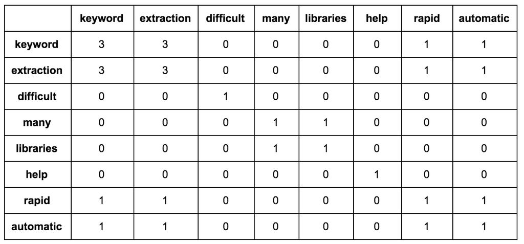

*RAKE Matrix*

*After that matrix is built, words are given a score. That score can be calculated as the degree of a word in the matrix (i.e. the sum of the number of co-occurrences the word has with any other content word in the text), as the word frequency (i.e. the number of times the word appears in the text), or as the degree of the word divided by its frequency.*

*If we were to compute the degree score divided by the frequency score for each of the words in our example, they would look like this:*

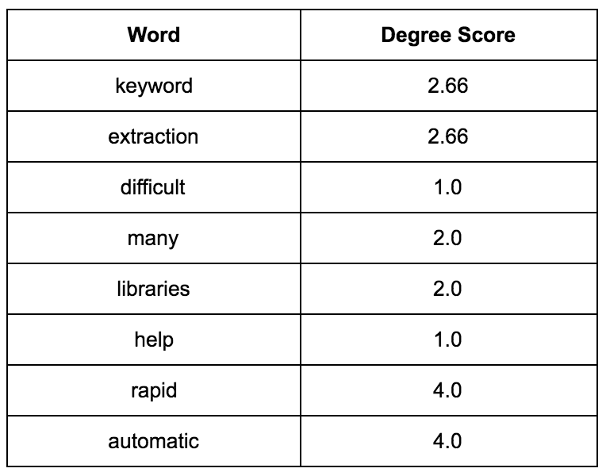

*RAKE frequency score*

*Those expressions are also given a score, which is computed as the sum of the individual scores of words. If we were to calculate the score of the phrases in bold above, they would look like this:*

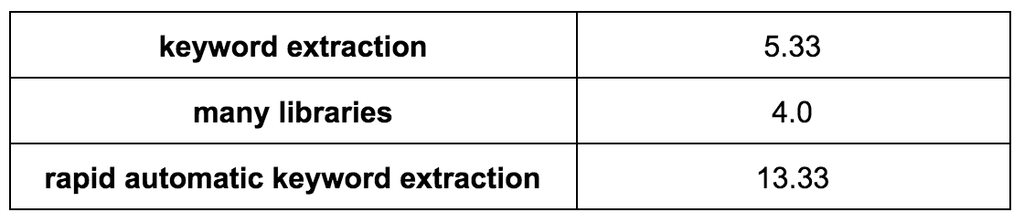

*RAKE phrases*

*If two keywords or keyphrases appear together in the same order more than twice, a new keyphrase is created regardless of how many stopwords the keyphrase contains in the original text. The score of that keyphrase is computed just like the one for a single keyphrase.*

*A keyword or keyphrase is chosen if its score belongs to the top T scores where T is the number of keywords you want to extract. According to the original paper, T defaults to one third of the content words in the document.*

*For the example above, the method would have returned the top 3 keywords, which, according to the score we have defined, would have been rapid automatic keyword extraction (13.33), keyword extraction (5.33), and many libraries (4.0).*

## *Linguistic Approaches*

*Keyword extraction methods often make use of linguistic information about texts and the words they contain. We are not going to describe all of the pieces of information that have been used to date, but here’s some of them.*

*Sometimes, morphological or syntactic information, such as the part-of-speech of words or the relations between words in a dependency grammar representation of sentences, is used to determine what keywords should be extracted. In some cases, certain PoS are given higher scores (e.g. nouns and noun phrases) since they usually contain more information about texts than other categories.*

*Some other methods make use of discourse markers (i.e. phrases that organize discourse into segments, such as however or moreover) or semantic information about the words (e.g. the shades of meaning of a given word).*

## *Graph-based Approaches*

*A graph can be defined as a set of vertices with connections between them.*

*A text can be represented as a graph in different ways. Words can be considered vertices that are connected by a directed edge (i.e. a one-way connection between the vertices). Those edges can be labeled, for instance, as the relation that the words have in a dependency tree. Other representations of documents might make use of undirected edges, for example, when representing word co-occurrences.*

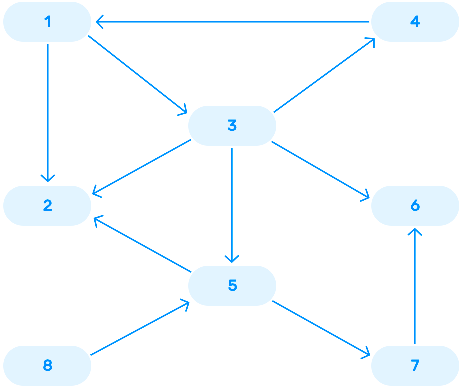

*The underlying idea in graph-based keyword extraction is always the same: measuring how important a vertex is based on measures that take into consideration some information obtained from the structure of the graph extract the most important vertices.*

*Once a graph has been built, it’s time to determine how to measure the importance of the vertices.*

## *Machine Learning Approaches*

*Machine learning-based systems can be used for many text analysis tasks, including keyword extraction.*

*There are different machine learning algorithms and techniques that can be used to extract the most relevant keywords in a text, including Support Vector Machines (SVM) and deep learning.*

*Below is one of the most common and effective approaches for keyword extraction with machine learning:*

*Conditional Random Fields*

*Conditional Random Fields (CRF) is a statistical approach that learns patterns by weighting different features in a sequence of words present in a text. This approach considers context and relationships between different variables in order to make its predictions.*

*Using conditional random fields allows you to create complex and rich patterns. Another advantage of this approach is its capacity to generalize; once the model has been trained with examples from a certain domain, it can easily apply what it has learned to other fields.*

*On the downside, in order to use conditional random fields you need to have strong computational skills to calculate the weight of all the features for all the sequences of words.*

## *Evaluating Performance of Keyword Extractors*

*When it comes to evaluating the performance of keyword extractors, you can use some of the standard metrics in machine learning: accuracy, precision, recall, and F1 score. However, these metrics don’t reflect partial matches; they only consider the perfect match between an extracted segment and the correct prediction for that tag.*

*Fortunately, there are some other metrics capable of capturing partial matches. An example of this is ROUGE.*

### *ROUGE*

*ROUGE (recall-oriented understudy for gisting evaluation)* is a family of metrics that compares different parameters (like the number of overlapping words) between the source text and the extracted words. The parameters include lengths and numbers of sequences and can be defined manually._

## *Codes*

```python
import numpy as np
import matplotlib.pyplot as plt
import pandas

# load the dataset
dataset = pandas.read_csv(r'C:\Users\PiyushSin\Data Science\NLP\datasets\arxiv papers.csv')
dataset.head()
```

|  | Abstract | Arxiv Link | Github Link | ID | Title |
| --- | --- | --- | --- | --- | --- |
| 0 | Discourse structures are beneficial for vari... | http://arxiv.org/abs/1812.00176 | github.com/irit-melodi/irit-stac | 1812.00176 | A Deep Sequential Model for Discourse Parsing ... |
| 1 | Learning good representations is of crucial ... | http://arxiv.org/abs/1812.00271 | github.com/mravanelli/SincNet/ | 1812.00271 | Learning Speaker Representations with Mutual I... |
| 2 | The explosive growth in fake news and its er... | http://arxiv.org/abs/1812.00315 | github.com/borisveytsman/acmart/issues/138 | 1812.00315 | Fake News: A Survey of Research, Detection Met... |
| 3 | The amount of dialogue history to include in... | http://arxiv.org/abs/1812.00350 | github.com/keras-team/keras | 1812.00350 | A Study on Dialogue Reward Prediction for Open... |
| 4 | Detecting controversy in general web pages i... | http://arxiv.org/abs/1812.00382 | github.com/aboSamoor/polyglot | 1812.00382 | Improved and Robust Controversy Detection in G... |

```python
#Fetch wordcount for each abstract
dataset['word_count'] = dataset['Abstract'].apply(lambda x: len(str(x).split(" ")))
dataset[['Abstract','word_count']].head()
```

|  | Abstract | word_count |
| --- | --- | --- |
| 0 | Discourse structures are beneficial for vari... | 149 |
| 1 | Learning good representations is of crucial ... | 175 |
| 2 | The explosive growth in fake news and its er... | 144 |
| 3 | The amount of dialogue history to include in... | 142 |
| 4 | Detecting controversy in general web pages i... | 159 |

```python
##Descriptive statistics of word counts
dataset.word_count.describe()
```

```
count    106.000000
mean     142.424528
std       44.912815
min       55.000000
25%      111.000000
50%      140.000000
75%      176.750000
max      247.000000
Name: word_count, dtype: float64
```

```python
#Identify common words
freq = pandas.Series(' '.join(dataset['Abstract']).split()).value_counts()[:20]
freq
```

```
the      690
of       474
and      459
a        379
to       378
in       258
for      204
on       183
is       157
we       152
that     148
with     139
as       123
We       109
model    105
an       104
this     103
by        90
our       90
In        88
dtype: int64
```

```python
#Identify uncommon words
freq1 =  pandas.Series(' '.join(dataset
         ['Abstract']).split()).value_counts()[-20:]
freq1
```

```
Additionally,        1
visualize            1
parametrized         1
algorithm,           1
E-commerce           1
7                    1
inference,           1
weakly-supervised    1
multi-aspect         1
recordings           1
listener.            1
converging           1
political            1
hand                 1
(near)               1
contain              1
over-fitting,        1
yet                  1
overcoming           1
exclusive            1
dtype: int64
```

```python
# Libraries for text preprocessing
import re
import nltk
nltk.download('stopwords')
from nltk.corpus import stopwords
from nltk.stem.porter import PorterStemmer
from nltk.tokenize import RegexpTokenizer
nltk.download('wordnet')
from nltk.stem.wordnet import WordNetLemmatizer
```

```python
##Creating a list of stop words and adding custom stopwords
stop_words = set(stopwords.words("english"))
```

```python
corpus = []
for i in range(0, 106):
    #Remove punctuations
    text = re.sub('[^a-zA-Z]', ' ', dataset['Abstract'][i])
    #Convert to lowercase
    text = text.lower()
    #remove tags
    text=re.sub("&lt;/?.*?&gt;"," &lt;&gt; ",text)
    # remove special characters and digits
    text=re.sub("(\\d|\\W)+"," ",text)
    ##Convert to list from string
    text = text.split()

    ##Stemming
    ps=PorterStemmer()
    #Lemmatisation
    lem = WordNetLemmatizer()
    text = [lem.lemmatize(word) for word in text if not word in
            stop_words]
    text = " ".join(text)
    corpus.append(text)
```

### *WordCloud*

```
<wordcloud.wordcloud.WordCloud object at 0x00000165C626EA90>
```

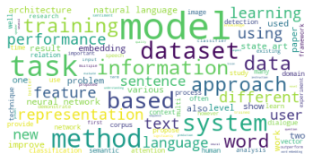

```python
# Word cloud

from os import path
from PIL import Image
from wordcloud import WordCloud, STOPWORDS, ImageColorGenerator
import matplotlib.pyplot as plt
%matplotlib inline

wordcloud = WordCloud(background_color='white',
                          stopwords=stop_words,
                          max_words=100,
                          max_font_size=50,
                          random_state=42
                         ).generate(str(corpus))
print(wordcloud)

fig = plt.figure(1)
plt.imshow(wordcloud)
plt.axis('off')
plt.show()
```

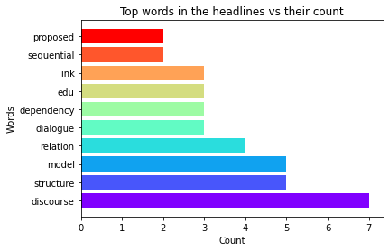

```python
import collections
from collections import Counter
from matplotlib import cm

counted_words = collections.Counter(corpus[0].split(' '))

words = []
counts = []
for letter, count in counted_words.most_common(10):
    words.append(letter)
    counts.append(count)

colors = cm.rainbow(np.linspace(0, 1, 10))

plt.title('Top words in the headlines vs their count')
plt.xlabel('Count')
plt.ylabel('Words')
plt.barh(words, counts, color=colors)
plt.show()
```

```python
from sklearn.feature_extraction.text import CountVectorizer
import re
cv=CountVectorizer(max_df=0.8,stop_words=stop_words, max_features=10000, ngram_range=(1,3))
X=cv.fit_transform(corpus)
```

```python
list(cv.vocabulary_.keys())[:10]
```

```
['discourse',
 'structure',
 'various',
 'nlp',
 'task',
 'dialogue',
 'understanding',
 'question',
 'answering',
 'sentiment']
```

### *Word Frequency*

[output not shown]

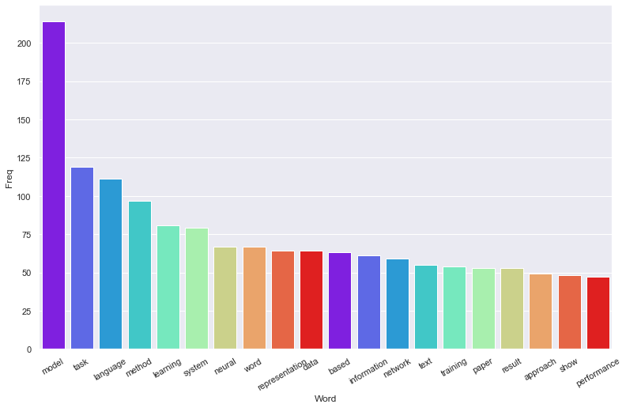

```python
# Most frequently occuring words

def get_top_n_words(corpus, n=None):
    vec = CountVectorizer().fit(corpus)
    bag_of_words = vec.transform(corpus)

    sum_words = bag_of_words.sum(axis=0)

    words_freq = [(word, sum_words[0, idx]) for word, idx in vec.vocabulary_.items()]

    words_freq =sorted(words_freq, key = lambda x: x[1], reverse=True)
    return words_freq[:n]

#Convert most freq words to dataframe for plotting bar plot
top_words = get_top_n_words(corpus, n=20)
top_df = pandas.DataFrame(top_words)
top_df.columns=["Word", "Freq"]

#Barplot of most freq words
import seaborn as sns
sns.set(rc={'figure.figsize':(13,8)})
colors = cm.rainbow(np.linspace(0, 1, 10))
g = sns.barplot(x="Word", y="Freq", data=top_df,palette = colors)
g.set_xticklabels(g.get_xticklabels(), rotation=30)
```

### *BiGrams*

```
                Bi-gram  Freq
0      natural language    35
1        neural network    34
2             state art    27
3   language processing    15
4   machine translation    15
5    sentiment analysis    14
6         deep learning    14
7            real world    14
8   experimental result    13
9     language modeling    13
10              end end    11
11          large scale    11
12      word embeddings    10
13     machine learning    10
14       self attention    10
15          result show    10
16        propose novel    10
17     answer selection    10
18        paper propose    10
19       language model    10
```

[output not shown]

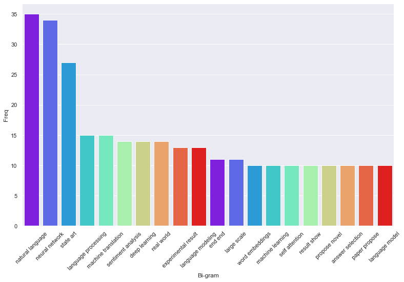

```python
# Most frequently occuring Bi-grams

def get_top_n2_words(corpus, n=None):
    vec1 = CountVectorizer(ngram_range=(2,2), max_features=2000).fit(corpus)
    bag_of_words = vec1.transform(corpus)

    sum_words = bag_of_words.sum(axis=0)

    words_freq = [(word, sum_words[0, idx]) for word, idx in vec1.vocabulary_.items()]

    words_freq =sorted(words_freq, key = lambda x: x[1], reverse=True)
    return words_freq[:n]

top2_words = get_top_n2_words(corpus, n=20)
top2_df = pandas.DataFrame(top2_words)
top2_df.columns=["Bi-gram", "Freq"]
print(top2_df)

#Barplot of most freq Bi-grams
import seaborn as sns
sns.set(rc={'figure.figsize':(13,8)})
h=sns.barplot(x="Bi-gram", y="Freq", data=top2_df,palette = colors)
h.set_xticklabels(h.get_xticklabels(), rotation=45)
```

### *TriGrams*

```
                          Tri-gram  Freq
0      natural language processing    14
1          language processing nlp     8
2                    new state art     8
3       neural machine translation     7
4   natural language understanding     7
5              deep neural network     6
6             binary code analysis     6
7             global anchor method     6
8              multi task learning     5
9             neural network model     5
10           masked language model     5
11    convolutional neural network     4
12        experimental result show     4
13             real world datasets     4
14                   set new state     4
15                state art result     4
16        named entity recognition     4
17  abstractive text summarization     4
18                   seq seq model     4
19         machine translation nmt     4
```

[output not shown]

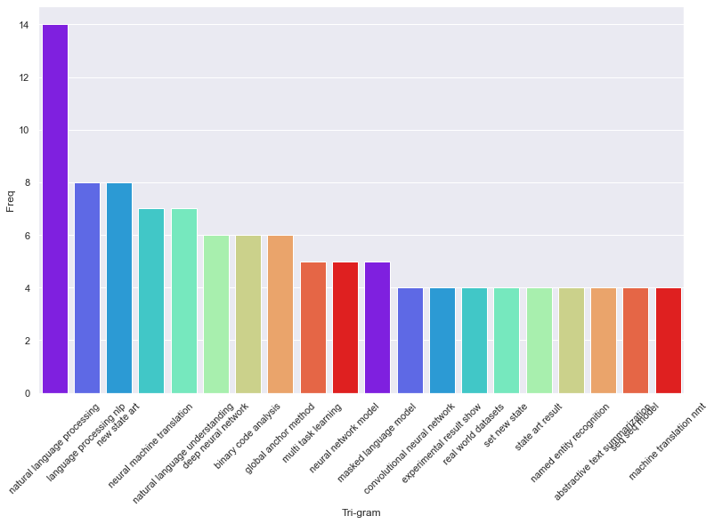

```python
# Most frequently occuring Tri-grams

def get_top_n3_words(corpus, n=None):
    vec1 = CountVectorizer(ngram_range=(3,3),max_features=2000).fit(corpus)

    bag_of_words = vec1.transform(corpus)

    sum_words = bag_of_words.sum(axis=0)

    words_freq = [(word, sum_words[0, idx]) for word, idx in vec1.vocabulary_.items()]
    words_freq =sorted(words_freq, key = lambda x: x[1], reverse=True)
    return words_freq[:n]

top3_words = get_top_n3_words(corpus, n=20)
top3_df = pandas.DataFrame(top3_words)
top3_df.columns=["Tri-gram", "Freq"]
print(top3_df)

#Barplot of most freq Tri-grams
import seaborn as sns
sns.set(rc={'figure.figsize':(13,8)})
j=sns.barplot(x="Tri-gram", y="Freq", data=top3_df,palette = colors)
j.set_xticklabels(j.get_xticklabels(), rotation=45)
```

### *TF-IDF*

```python
from sklearn.feature_extraction.text import TfidfTransformer

tfidf_transformer=TfidfTransformer(smooth_idf=True,use_idf=True)
tfidf_transformer.fit(X)
# get feature names
feature_names=cv.get_feature_names()

# fetch document for which keywords needs to be extracted
doc=corpus[103]

#generate tf-idf for the given document
tf_idf_vector=tfidf_transformer.transform(cv.transform([doc]))
tf_idf_vector
```

```
<1x10000 sparse matrix of type '<class 'numpy.float64'>'
	with 333 stored elements in Compressed Sparse Row format>
```

```python
# Function for sorting tf_idf in descending order
from scipy.sparse import coo_matrix

def sort_coo(coo_matrix):
    tuples = zip(coo_matrix.col, coo_matrix.data)
    return sorted(tuples, key=lambda x: (x[1], x[0]), reverse=True)

def extract_topn_from_vector(feature_names, sorted_items, topn=10):
    """get the feature names and tf-idf score of top n items"""

    #use only topn items from vector
    sorted_items = sorted_items[:topn]

    score_vals = []
    feature_vals = []

    # word index and corresponding tf-idf score
    for idx, score in sorted_items:

        #keep track of feature name and its corresponding score
        score_vals.append(round(score, 3))
        feature_vals.append(feature_names[idx])

    #create a tuples of feature,score
    #results = zip(feature_vals,score_vals)
    results= {}
    for idx in range(len(feature_vals)):
        results[feature_vals[idx]]=score_vals[idx]

    return results
#sort the tf-idf vectors by descending order of scores
sorted_items=sort_coo(tf_idf_vector.tocoo())
#extract only the top n; n here is 10
keywords=extract_topn_from_vector(feature_names,sorted_items,5)

# now print the results
print("\nAbstract:")
print(doc)
print("\nKeywords:")
for k in keywords:
    print(k,keywords[k])
```

```
Abstract:
volume scholarly publication increased frenetic pace accessing consuming useful candidate paper large digital library becoming essential challenging task scholar unfortunately language barrier scientist especially junior one graduate student master language cannot efficiently locate publication host…

Keywords:
publication 0.194
cross language 0.158
language 0.123
graph 0.11
cross 0.11
```

### *TextRank*

```python
import spacy
import pytextrank

# example text
text = """
When it comes to evaluating the performance of keyword extractors, you can use some of the standard metrics in machine learning: accuracy, precision, recall, and F1 score. However, these metrics don’t reflect partial matches. they only consider the perfect match between an extracted segment and the correct prediction for that tag.
Fortunately, there are some other metrics capable of capturing partial matches. An example of this is ROUGE.
"""
# load a spaCy model, depending on language, scale, etc.
nlp = spacy.load("en_core_web_sm")


# add PyTextRank to the spaCy pipeline
tr = pytextrank.TextRank()
nlp.add_pipe(tr.PipelineComponent, name="textrank", last=True)

doc = nlp(text)

# examine the top-ranked phrases in the document
for p in doc._.phrases[:10]:
    print(p.text)
```

```
partial matches
keyword extractors
machine learning
f1 score
f1
accuracy
recall
precision
the perfect match
the standard metrics
```

### *spaCy POS Tagging*

```python
import spacy
from collections import Counter
from string import punctuation
nlp = spacy.load("en_core_web_sm")

def get_hotwords(text):
    result = []
    pos_tag = ['PROPN', 'ADJ', 'NOUN'] # 1
    doc = nlp(text.lower()) # 2
    for token in doc:
        # 3
        if(token.text in nlp.Defaults.stop_words or token.text in punctuation):
            continue
        # 4
        if(token.pos_ in pos_tag):
            result.append(token.text)

    return result # 5

new_text = """
When it comes to evaluating the performance of keyword extractors, you can use some of the standard metrics in machine learning: accuracy, precision, recall, and F1 score. However, these metrics don’t reflect partial matches. they only consider the perfect match between an extracted segment and the correct prediction for that tag.
Fortunately, there are some other metrics capable of capturing partial matches. An example of this is ROUGE.
"""
output = set(get_hotwords(new_text))
most_common_list = Counter(output).most_common(10)
for item in most_common_list:
    print(item[0])
```

```
learning
keyword
accuracy
partial
extractors
f1
performance
recall
matches
match
```

### *RAKE*

```python
from rake_nltk import Rake
r = Rake()

my_text = """
When it comes to evaluating the performance of keyword extractors, you can use some of the standard metrics in machine learning: accuracy, precision, recall, and F1 score. However, these metrics don’t reflect partial matches; they only consider the perfect match between an extracted segment and the correct prediction for that tag.
Fortunately, there are some other metrics capable of capturing partial matches. An example of this is ROUGE.
"""
r.extract_keywords_from_text(my_text)

keywordList = []
rankedList = r.get_ranked_phrases_with_scores()
```

```python
rankedList
```

```
[(9.0, 'reflect partial matches'),
 (9.0, 'capturing partial matches'),
 (4.0, 'perfect match'),
 (4.0, 'machine learning'),
 (4.0, 'keyword extractors'),
 (4.0, 'f1 score'),
 (4.0, 'extracted segment'),
 (4.0, 'correct prediction'),
 (3.666666666666667, 'standard metrics'),
 (3.666666666666667, 'metrics capable'),
 (1.6666666666666667, 'metrics'),
 (1.0, '’'),
 (1.0, 'use'),
 (1.0, 'tag'),
 (1.0, 'rouge'),
 (1.0, 'recall'),
 (1.0, 'precision'),
 (1.0, 'performance'),
 (1.0, 'however'),
 (1.0, 'fortunately'),
 (1.0, 'example'),
 (1.0, 'evaluating'),
 (1.0, 'consider'),
 (1.0, 'comes'),
 (1.0, 'accuracy')]
```

```python
for keyword in rankedList:
    #print(keyword)
    keyword_updated = keyword[1].split()
    #print(keyword_updated)
    keyword_updated_string = " ".join(keyword_updated[:2])
    keywordList.append(keyword_updated_string)

    if(len(keywordList)>9):
        break

print(keywordList)
```

```
['reflect partial', 'capturing partial', 'perfect match', 'machine learning', 'keyword extractors', 'f1 score', 'extracted segment', 'correct prediction', 'standard metrics', 'metrics capable']
```